# RC1_Linear_Regression

Haohong Shang

2023-05-14

This slide is created by UM’s GSI.

## Import dataset

We’ll work with the Auto dataset from the Lab 1 exercise

```r
library(ISLR)

data(Auto)
# what are the variables?
names(Auto)
```

```
## [1] "mpg"          "cylinders"    "displacement" "horsepower"   "weight"
## [6] "acceleration" "year"         "origin"       "name"
```

The ISLR package provides a more detailed description if you type ?Auto in the console.

We’ll begin by fitting a simple linear regression to predict mpg given horsepower using the lm function.

## Fitting simple linear regression with lm

```r
attach(Auto)

# basic syntax is lm(y~x), which produces a linear model object
lm.fit <- lm(mpg~horsepower)
```

## Inspect fitted model

We can see basic output by printing lm.fit. More detailed output is given by calling summary(lm.fit), incluing R-squared, and standard errors of coefficients.

You should make yourself familiar with all the information in the summary output.

```r
# basic lm output
lm.fit
```

```
##
## Call:
## lm(formula = mpg ~ horsepower)
##
## Coefficients:
## (Intercept)   horsepower
##     39.9359      -0.1578
```

```r
# detailed lm output
summary(lm.fit)
```

```
##
## Call:
## lm(formula = mpg ~ horsepower)
##
## Residuals:
##      Min       1Q   Median       3Q      Max
## -13.5710  -3.2592  -0.3435   2.7630  16.9240
##
## Coefficients:
##              Estimate Std. Error t value Pr(>|t|)
## (Intercept) 39.935861   0.717499   55.66   <2e-16 ***
## horsepower  -0.157845   0.006446  -24.49   <2e-16 ***
## ---
## Signif. codes:  0 '***' 0.001 '**' 0.01 '*' 0.05 '.' 0.1 ' ' 1
##
## Residual standard error: 4.906 on 390 degrees of freedom
## Multiple R-squared:  0.6059, Adjusted R-squared:  0.6049
## F-statistic: 599.7 on 1 and 390 DF,  p-value: < 2.2e-16
```

lm automatically produces some other objects we may be interested in (e.g. vector of residuals, vector of coefficients).

```r
# view the available lm objects
names(lm.fit)
```

```
##  [1] "coefficients"  "residuals"     "effects"       "rank"
##  [5] "fitted.values" "assign"        "qr"            "df.residual"
##  [9] "xlevels"       "call"          "terms"         "model"
```

```r
# there are two ways to access the coefficient vector, for instance
# (1)
lm.fit$coefficients
```

```
## (Intercept)  horsepower
##  39.9358610  -0.1578447
```

```r
# (2)
coef(lm.fit)
```

```
## (Intercept)  horsepower
##  39.9358610  -0.1578447
```

R will automatically provide confidence intervals for the parameters of the fitted model, and predictions for new data

```r
# confidence intervals for coefficient vector
confint(lm.fit)
```

```
##                 2.5 %     97.5 %
## (Intercept) 38.525212 41.3465103
## horsepower  -0.170517 -0.1451725
```

```r
# predictions for new data (with error bounds)
predict(lm.fit,data.frame(horsepower=c(100,120,200)),interval="prediction")
```

```
##         fit       lwr      upr
## 1 24.151388 14.493888 33.80889
## 2 20.994493 11.335155 30.65383
## 3  8.366914 -1.365999 18.09983
```

## Plots and visual diagnostics

We can plot the fitted regression line with the abline function

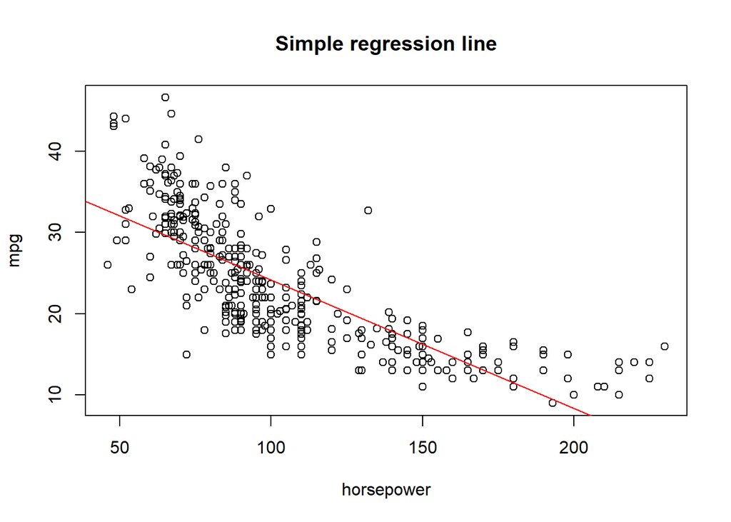

```r
# scatter plot of horsepower and mpg
plot(horsepower,mpg,main="Simple regression line")
# add regression line
abline(lm.fit,col="red")
```

R also produces four basic diagnostic plots with plot.lm:

- Residuals vs fitted values
- Residual QQ-plot
- Standardized residuals vs fitted values
- Standardized resiudals vs leverage

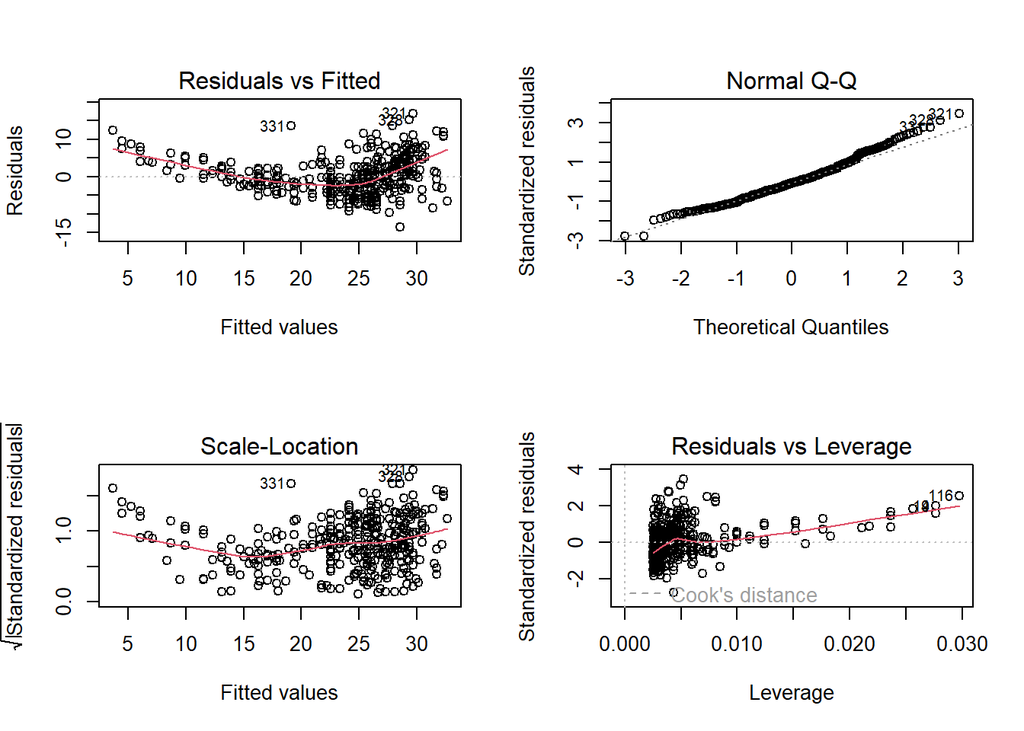

```r
# set plot options so all four plots appear in the same pane
par(mfrow=c(2,2))

# diagnostic plots
plot(lm.fit)
```

```r
# reset plot options
par(mfrow=c(1,1))
```

We can produce these plots ourselves by using the objects produced by lm, for instance suppose we want to see the residuals vs fitted values plot.

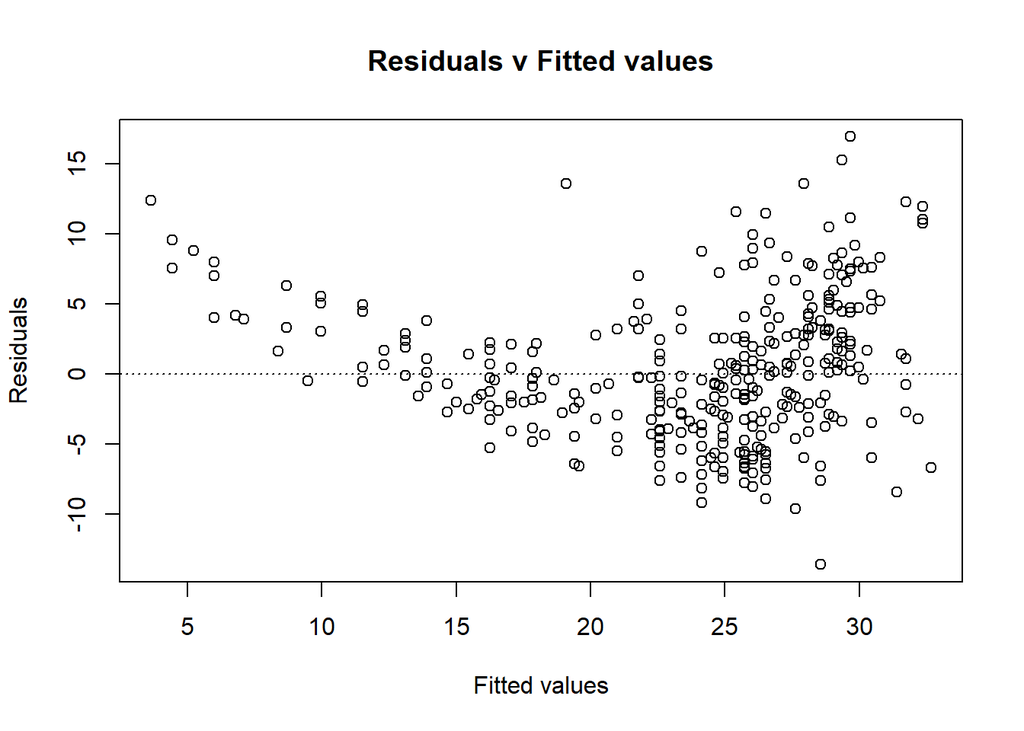

```r
# residuals v fitted values plot
y.hat <- predict(lm.fit)
e.hat <- residuals(lm.fit)
plot(y.hat,e.hat,
     xlab="Fitted values",ylab="Residuals",
     main="Residuals v Fitted values")
abline(h=0,lty=3)
```

## Fitting multiple regression with lm

Suppose we also think vehicle weight will influence fuel efficiency. To fit a multiple linear regression, simply add more variables to the formula in lm.

```r
# fit a multiple linear regression
mlm.fit <- lm(mpg~horsepower+weight)

# view summary output
summary(mlm.fit)
```

```
##
## Call:
## lm(formula = mpg ~ horsepower + weight)
##
## Residuals:
##      Min       1Q   Median       3Q      Max
## -11.0762  -2.7340  -0.3312   2.1752  16.2601
##
## Coefficients:
##               Estimate Std. Error t value Pr(>|t|)
## (Intercept) 45.6402108  0.7931958  57.540  < 2e-16 ***
## horsepower  -0.0473029  0.0110851  -4.267 2.49e-05 ***
## weight      -0.0057942  0.0005023 -11.535  < 2e-16 ***
## ---
## Signif. codes:  0 '***' 0.001 '**' 0.01 '*' 0.05 '.' 0.1 ' ' 1
##
## Residual standard error: 4.24 on 389 degrees of freedom
## Multiple R-squared:  0.7064, Adjusted R-squared:  0.7049
## F-statistic: 467.9 on 2 and 389 DF,  p-value: < 2.2e-16
```

A few things to note:

- Both predictors appear to have an influence on fuel efficiency
- The R-squared value has increased after adding another predictor
- The estimate of the coefficient for horsepower has changed

Suppose we want to add even more parameters to the model. The formula shortcut to add all variables is ‘.’ (**Warning**: the ‘.’ command is not compatible with ‘attach’, you’ll have to specify the dataset in the lm call)

However in this case, the data contains non-numeric variables ‘origin’ and ‘name’ which we we can remove from the model by subtracting them in the formula.

```r
# fit a multiple linear regression
mlm.fit.2 <- lm(mpg~.-origin-name,data=Auto)

# view summary output
summary(mlm.fit.2)
```

```
##
## Call:
## lm(formula = mpg ~ . - origin - name, data = Auto)
##
## Residuals:
##     Min      1Q  Median      3Q     Max
## -8.6927 -2.3864 -0.0801  2.0291 14.3607
##
## Coefficients:
##                Estimate Std. Error t value Pr(>|t|)
## (Intercept)  -1.454e+01  4.764e+00  -3.051  0.00244 **
## cylinders    -3.299e-01  3.321e-01  -0.993  0.32122
## displacement  7.678e-03  7.358e-03   1.044  0.29733
## horsepower   -3.914e-04  1.384e-02  -0.028  0.97745
## weight       -6.795e-03  6.700e-04 -10.141  < 2e-16 ***
## acceleration  8.527e-02  1.020e-01   0.836  0.40383
## year          7.534e-01  5.262e-02  14.318  < 2e-16 ***
## ---
## Signif. codes:  0 '***' 0.001 '**' 0.01 '*' 0.05 '.' 0.1 ' ' 1
##
## Residual standard error: 3.435 on 385 degrees of freedom
## Multiple R-squared:  0.8093, Adjusted R-squared:  0.8063
## F-statistic: 272.2 on 6 and 385 DF,  p-value: < 2.2e-16
```

## Fitting regression with transformed predictors with lm

Recall the plot we produced of residuals vs fitted values in our simple linear regression (y=mpg, x=horsepower). We can see a clear quadratic pattern in this plot, implying we could improve the fit by adding a quadratic term to our model.

There are three ways to do this:

1. Create a new column in the data frame

```r
# create a column containing the squared horsepower
Auto$horsepower2 <- horsepower^2

# fit a multiple linear regression on horsepower and horsepower^2
qm.fit <- lm(mpg~horsepower + horsepower2,data=Auto)

# view basic output
qm.fit
```

```
##
## Call:
## lm(formula = mpg ~ horsepower + horsepower2, data = Auto)
##
## Coefficients:
## (Intercept)   horsepower  horsepower2
##   56.900100    -0.466190     0.001231
```

2. Do the transformation directly in lm

```r
# fit a multiple linear regression
qm.fit2 <- lm(mpg~horsepower+I(horsepower^2))

# view basic output
qm.fit2
```

```
##
## Call:
## lm(formula = mpg ~ horsepower + I(horsepower^2))
##
## Coefficients:
##     (Intercept)       horsepower  I(horsepower^2)
##       56.900100        -0.466190         0.001231
```

3. Use the poly command to fit a higher order polynomial model

```r
# fit a multiple linear regression
qm.fit3 <- lm(mpg~poly(horsepower,2))

# view basic output
qm.fit3
```

```
##
## Call:
## lm(formula = mpg ~ poly(horsepower, 2))
##
## Coefficients:
##          (Intercept)  poly(horsepower, 2)1  poly(horsepower, 2)2
##                23.45               -120.14                 44.09
```

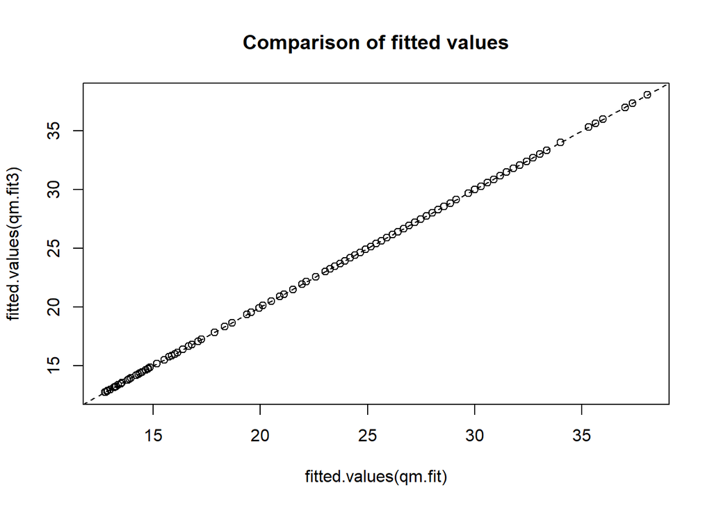

```r
# the poly command uses orthonormal polynomials, so it produces
# different coefficients but the same fitted values
plot(fitted.values(qm.fit),fitted.values(qm.fit3),
     main="Comparison of fitted values")
abline(a=0,b=1,lty=2)
```

The poly command can be used to fit even higher order polynomial models.

After adding a quadratic term, we have removed the pattern in the residual vs fitted value plot.

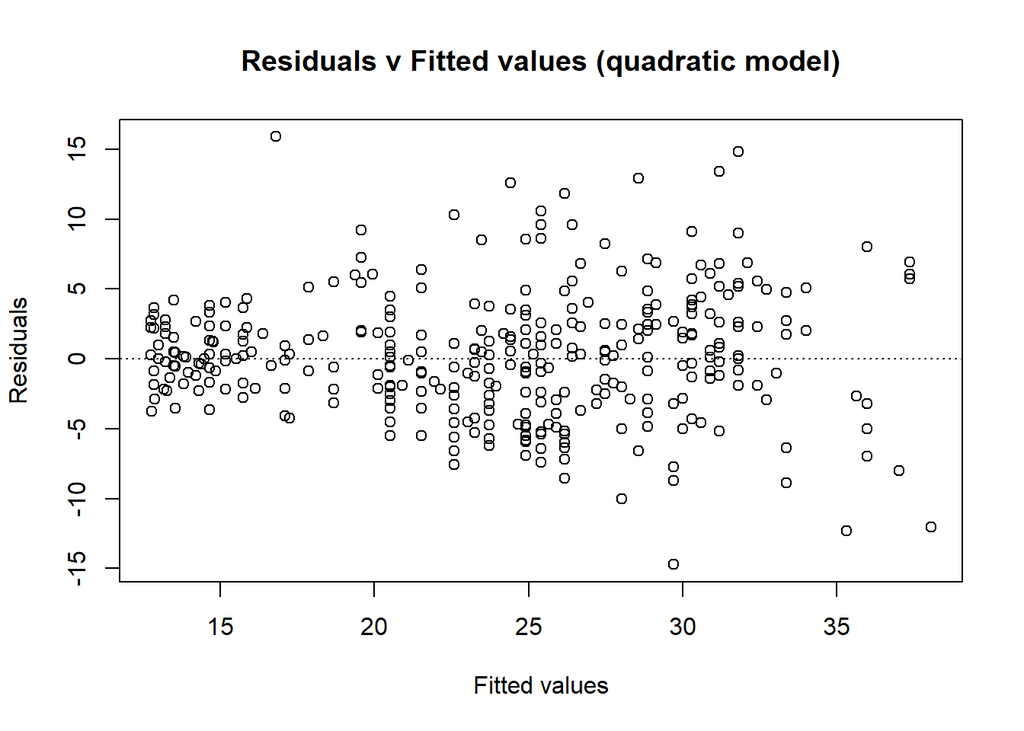

```r
# quadratic model residuals v fitted values plot
y.hat <- predict(qm.fit)
e.hat <- residuals(qm.fit)
plot(y.hat,e.hat,
     xlab="Fitted values",ylab="Residuals",
     main="Residuals v Fitted values (quadratic model)")
abline(h=0,lty=3)
```